# HW5

Xiaomeng Huang

11/4/2019

# 5.4

**a.** Since they sample all articles published during 1988 for the selected journals. This is a one-stage clustering. The clusters are the selected journals, and the observation unit is an article.

**b.**

```r
library(SDaA)
data("journal")
dat=journal
dat$indeterminate=dat$numemp-dat$prob-dat$nonprob
N=1285 #number of clusters/psus in the population
Mi=dat$numemp # number of observations/ssus in psu i
p=sum(journal$nonprob)/sum(journal$numemp)
```

**c.** The statement is questionable since clsuter sampling often decreases precision.

# 5.8

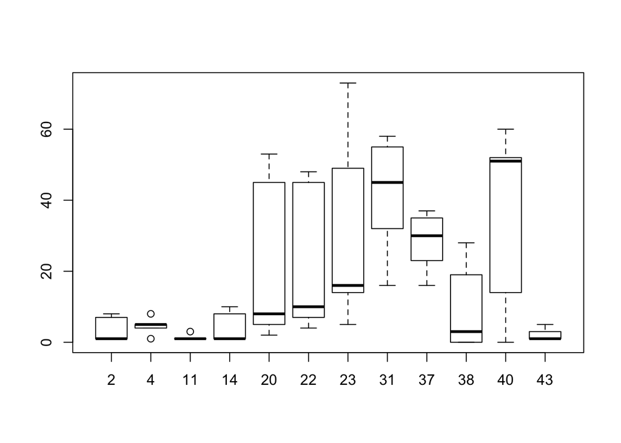

```r
dat=read.csv("books.csv")
boxplot(dat$purchase~dat$shelf)
```

**a.** It appears that both the means and variances are different. **b.**

```r
n=12;N=44
library(data.table)
dat=data.table(dat)
dat$mi=rep(5,nrow(dat))
tab=dat[,c(lapply(.SD, mean),
       lapply(.SD, var)),by=c("shelf","Mi","mi"),.SDcols="replace"]
names(tab)=c("shelf","Mi","mi","ybar","vy")
tab$t=tab$Mi*tab$ybar
head(tab)
```

```
##    shelf Mi mi ybar     vy     t
## 1:     2 26  5  9.6   17.8 249.6
## 2:     4 52  5  6.2    1.7 322.4
## 3:    11 70  5  9.2   18.7 644.0
## 4:    14 47  5  7.2    3.2 338.4
## 5:    20  5  5 41.8 2666.7 209.0
## 6:    22 28  5 29.8  748.7 834.4
```

```r
tunb=sum(tab$t)*N/n
tunb # estimate total replacement cost
```

```
## [1] 32637.73
```

```r
se=N*sqrt((1-n/N)*(var(tab$t)/n)+(1/(n*N))*sum((1-(tab$mi/tab$Mi))*(tab$Mi^2)*(tab$vy/tab$mi)))
se # standard error of estime total replacement cost
```

```
## [1] 5733.527
```

```r
se/tunb #estimated coefficient of variation
```

```
## [1] 0.1756717
```

```r
ybar=sum(tab$t)/sum(tab$Mi)
ybar #estimed average replacement cost per book
```

```
## [1] 23.61061
```

```r
s2=sum((tab$t-(tab$Mi*ybar))^2)/(n-1)
s2
```

```
## [1] 476700.3
```

```r
seybar=(1/mean(tab$Mi))*sqrt((1-n/N)*(s2/n)+(1/(n*N))*sum((1-(tab$mi/tab$Mi))*(tab$Mi^2)*(tab$vy/tab$mi)))
seybar# standard error of estimed average replacement cost per book
```

```
## [1] 5.475943
```

```r
seybar/ybar # estimated coefficient of variation for ybar
```

```
## [1] 0.2319272
```

# 5.11

**a.** $N=828,n=85,M=215,\bar{y}_U=\frac{1}{nM}\sum{\hat{t}_i}=\frac{4+3+4\times2+22}{85\times 215}=0.002024624$  
$s_t^2=\frac{1}{n-1}\sum(t_i-\bar{t}_S)^2=\frac{1}{84}(57(0-\frac{37}{85})^2+22(1-\frac{37}{85})^2+4(2-\frac{37}{85})^2+(3-\frac{37}{85})^2+(4-\frac{37}{85})^2)=0.5583$,  
$se(\bar{y}_U)=\sqrt{(1-\frac{n}{N})\frac{s_t^2}{nM^2}}=0.000357$  
**b.** $t=N\sum{\hat{t}_i}/n=360.42,se(t)=N\sqrt{(1-\frac{n}{N})\frac{s_t^2}{n}}=63.565$  
**c.** error rate: $\frac{37}{18275}=0.002025$, estimated variance: $V(p_{srs})=(1-\frac{18275}{178275})\frac{0.002025\times(1-0.002025)}{18274}=9.92\times10^{-8}$  
estimated variance from a: $V(\bar{y})=1.28\times10^{-7}$, which is $1.28\times10^{-7}/9.92\times10^{-8}=1.29$ times larger than the estimated variance using SRS.

# 5.19

```r
data("agsrs")
mod=anova(lm(acres92~state,data=agsrs))
R2=1- (mod$`Mean Sq`[2]/(sum(mod$`Sum Sq`)/299))
R2
```

```
## [1] 0.4953455
```

**a.** The estimated $R_a^2=0.4953$. There is a cluster effect.

```r
mbar=sqrt(15*(1-R2)/R2)
mbar
```

```
## [1] 3.909206
```

```r
n=300/4
n
```

```
## [1] 75
```